## Executive Summary

Six participants were asked to perform barbell lifts correctly and incorrectly in 5 different ways.Accelerometers were attached to the dumbbells, arm, forearm and belt of the participants to capture the movements. The goal of this project is to use the data captured to predict the manner in which they did the exercise.This is the “classe” variable in the data. “A” means the participant did the exercise correctly. “B” to “E” correspond to common mistakes.  
In this project we explored 2 prediction methods - decision tree and random forest. As expected random forest is a more accurate prediction machine which we adopted on the final test sets.It has an out of sample accuracy of 0.9983.

## Loading Data and cleaning it

```r
#Load required libraries
library(caret)
library(randomForest)
```

```r
library(ggplot2)
library(rattle)
library(rpart)
#Set the set for repeatability by others
set.seed(7638)
#Load data in directory.
traindata <- read.csv("pml-training.csv",header=TRUE)
testdata <- read.csv("pml-testing.csv",header=TRUE)
str(traindata)
```

```
## 'data.frame':    19622 obs. of  160 variables:
##  $ X                       : int  1 2 3 4 5 6 7 8 9 10 ...
##  $ user_name               : Factor w/ 6 levels "adelmo","carlitos",..: 2 2 2 2 2 2 2 2 2 2 ...
##  $ raw_timestamp_part_1    : int  1323084231 1323084231 1323084231 1323084232 1323084232 1323084232 1323084232 1323084232 1323084232 1323084232 ...
##  $ raw_timestamp_part_2    : int  788290 808298 820366 120339 196328 304277 368296 440390 484323 484434 ...
##  $ cvtd_timestamp          : Factor w/ 20 levels "02/12/2011 13:32",..: 9 9 9 9 9 9 9 9 9 9 ...
##  $ new_window              : Factor w/ 2 levels "no","yes": 1 1 1 1 1 1 1 1 1 1 ...
##  $ num_window              : int  11 11 11 12 12 12 12 12 12 12 ...
##  $ roll_belt               : num  1.41 1.41 1.42 1.48 1.48 1.45 1.42 1.42 1.43 1.45 ...
##  $ pitch_belt              : num  8.07 8.07 8.07 8.05 8.07 8.06 8.09 8.13 8.16 8.17 ...
##  $ yaw_belt                : num  -94.4 -94.4 -94.4 -94.4 -94.4 -94.4 -94.4 -94.4 -94.4 -94.4 ...
##  $ total_accel_belt        : int  3 3 3 3 3 3 3 3 3 3 ...
##  $ kurtosis_roll_belt      : Factor w/ 397 levels "","-0.016850",..: 1 1 1 1 1 1 1 1 1 1 ...
##  $ kurtosis_picth_belt     : Factor w/ 317 levels "","-0.021887",..: 1 1 1 1 1 1 1 1 1 1 ...
##  $ kurtosis_yaw_belt       : Factor w/ 2 levels "","#DIV/0!": 1 1 1 1 1 1 1 1 1 1 ...
```

[output cut: 86 more lines]

From the data we see that there are many NAs and also DIV/0. These will be removed to produce a tidy data.

```r
#Remove columns with NA & DIV/0
cleantraindata <- traindata[,colSums(is.na(traindata))==0]
cleantraindata<-cleantraindata[,colSums(cleantraindata=="#DIV/0!")==0]
cleantestdata <- testdata[,colSums(is.na(testdata))==0]
cleantestdata<-cleantestdata[,colSums(cleantestdata=="#DIV/0!")==0]
```

The data is now down to 60 variables.

## Splitting data into training and testing set for cross validation

```r
#Partition cleantraindata into training set and test set
x <- createDataPartition(cleantraindata$classe,p=0.7,list=FALSE)
training <- cleantraindata[x,]
testing <- cleantraindata[-x,]
dim(training); dim(testing)
```

```
## [1] 13737    60
```

```
## [1] 5885   60
```

We chose a split of 70/30 to produce training and test sets from the original training set for cross validation purpose. Let’s examine the data using the training set

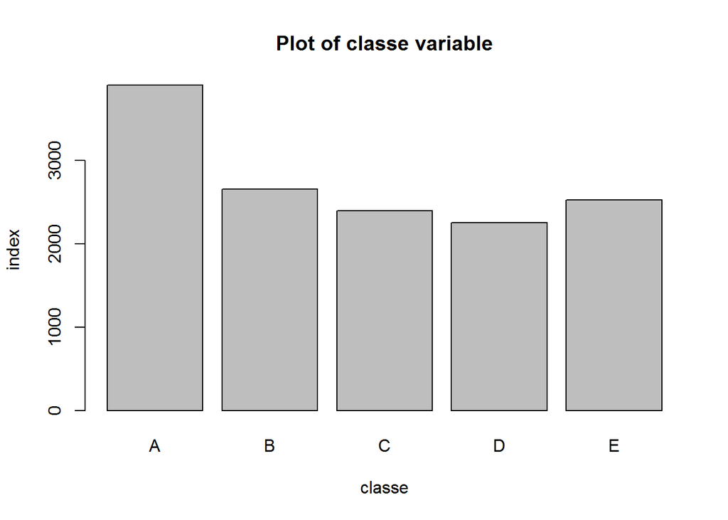

Indeed the classe variable is factor “A” to “E”.  
Now we perform the 2 predictions. For each we test the model against the testing set created from the original pml-training.csv data. Then we compare the 2 prediction machine and select the more accurate one. We use confusionMatrix to compute the accuracy.

## Prediction 1 - Decision Tree

```r
#Use decision tree to predict. Remove 1st column to avoid confusing ML
#Note that somehow using the train() function from caret package the rpart runs very slowly compared to using rpart().
tree.model <- rpart(classe ~ ., data=training[2:60], method="class")
tree.predict <- predict(tree.model,newdata=testing[2:60],type="class")
confusionMatrix(tree.predict,testing$classe)
```

```
## Confusion Matrix and Statistics
##
##           Reference
## Prediction    A    B    C    D    E
##          A 1617   47    6    0    0
##          B   49  984   89   62    0
##          C    8  101  915  156   39
##          D    0    7   11  582   62
##          E    0    0    5  164  981
##
## Overall Statistics
##
##                Accuracy : 0.863
##                  95% CI : (0.854, 0.8717)
##     No Information Rate : 0.2845
##     P-Value [Acc > NIR] : < 2.2e-16
##
##                   Kappa : 0.8266
##  Mcnemar's Test P-Value : NA
##
## Statistics by Class:
##
##                      Class: A Class: B Class: C Class: D Class: E
## Sensitivity            0.9659   0.8639   0.8918   0.6037   0.9067
## Specificity            0.9874   0.9579   0.9374   0.9837   0.9648
## Pos Pred Value         0.9683   0.8311   0.7506   0.8792   0.8530
## Neg Pred Value         0.9865   0.9670   0.9762   0.9269   0.9787
## Prevalence             0.2845   0.1935   0.1743   0.1638   0.1839
## Detection Rate         0.2748   0.1672   0.1555   0.0989   0.1667
## Detection Prevalence   0.2838   0.2012   0.2071   0.1125   0.1954
## Balanced Accuracy      0.9767   0.9109   0.9146   0.7937   0.9357
```

The out of sample accuracy as noted for this model is 0.863. Let’s plot the decision tree.

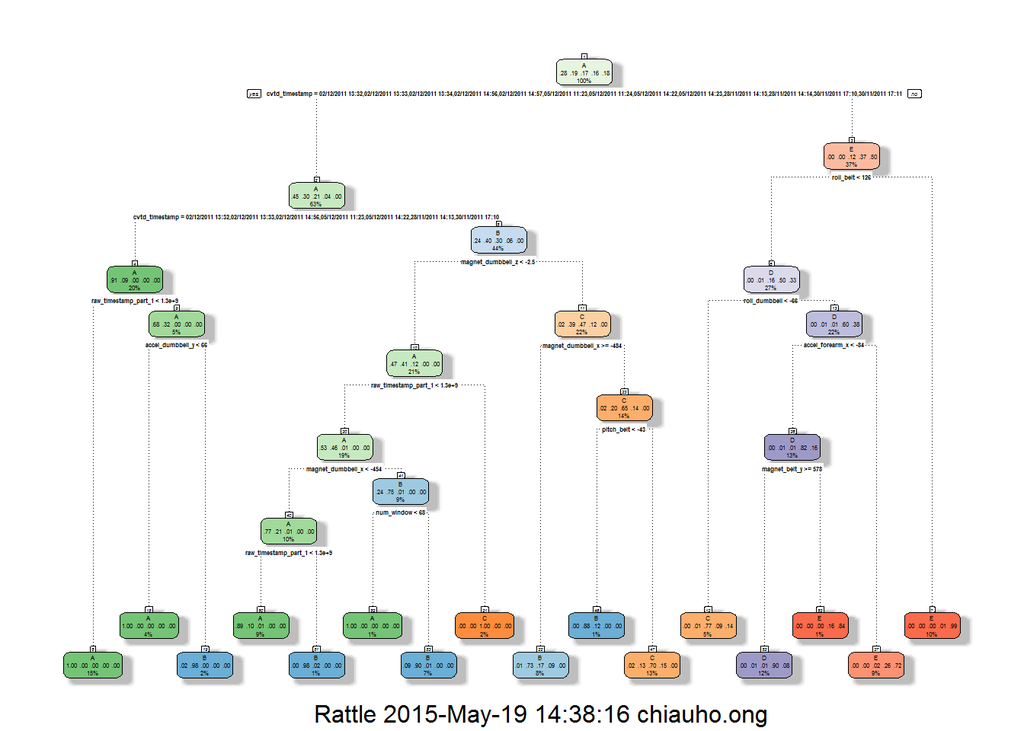

```r
#Plot tree
fancyRpartPlot(tree.model)
```

## Prediction 2 - Random Forest

```r
#Use randomForest to predict
#Again for some reason using the caret package the RandomForest executes very slowly.
rf.model <- randomForest(classe ~. , data=training[2:60])
rf.predict <- predict(rf.model,testing[2:60],type="class")
confusionMatrix(rf.predict,testing$classe)
```

```
## Confusion Matrix and Statistics
##
##           Reference
## Prediction    A    B    C    D    E
##          A 1674    0    0    0    0
##          B    0 1139    0    0    0
##          C    0    0 1025    5    0
##          D    0    0    1  956    1
##          E    0    0    0    3 1081
##
## Overall Statistics
##
##                Accuracy : 0.9983
##                  95% CI : (0.9969, 0.9992)
##     No Information Rate : 0.2845
##     P-Value [Acc > NIR] : < 2.2e-16
##
##                   Kappa : 0.9979
##  Mcnemar's Test P-Value : NA
##
## Statistics by Class:
##
##                      Class: A Class: B Class: C Class: D Class: E
## Sensitivity            1.0000   1.0000   0.9990   0.9917   0.9991
## Specificity            1.0000   1.0000   0.9990   0.9996   0.9994
## Pos Pred Value         1.0000   1.0000   0.9951   0.9979   0.9972
## Neg Pred Value         1.0000   1.0000   0.9998   0.9984   0.9998
## Prevalence             0.2845   0.1935   0.1743   0.1638   0.1839
## Detection Rate         0.2845   0.1935   0.1742   0.1624   0.1837
## Detection Prevalence   0.2845   0.1935   0.1750   0.1628   0.1842
## Balanced Accuracy      1.0000   1.0000   0.9990   0.9956   0.9992
```

The out of sample accuracy of Random Forest is 0.9983 which is much more accurate than Decision Tree. This is to be expected. We will use this model to predict the actual test data.

## Conclusion

Two models were generated, one using Decision Tree and the other the Random Forest. The Random Forest was picked over Decision Tree as it was more accurate, having an out of sample accuracy of 0.9983 versus 0.863 using the Tree.